This script will cover the Exploratory Data Analysis (EDA) shown in R for Data Science and may go a bit further

EDA is a cyclical process of 1. Generating questions about data 2. Searching for answers in the data using summary stats and visualizations along with models 3. Generating more educated questions based on these insights to form even more refined insights

```r
library(tidyverse)
library(magrittr)
```

Two questions that are often helpful to start with are 1. What type of variation occurs within my variables 2. What type of covariation occurs between my variables

# Visualizing distributions

What is the distribution of the cut of diamonds in my dataset

```r
diamonds %>%
  count(cut)
```

| cut | n |
| --- | --- |
| Fair | 1610 |
| Good | 4906 |
| Very Good | 12082 |
| Premium | 13791 |
| Ideal | 21551 |

hmm this is intriguing but maybe it would be better to see this information in a graphic form, such as a bargraph

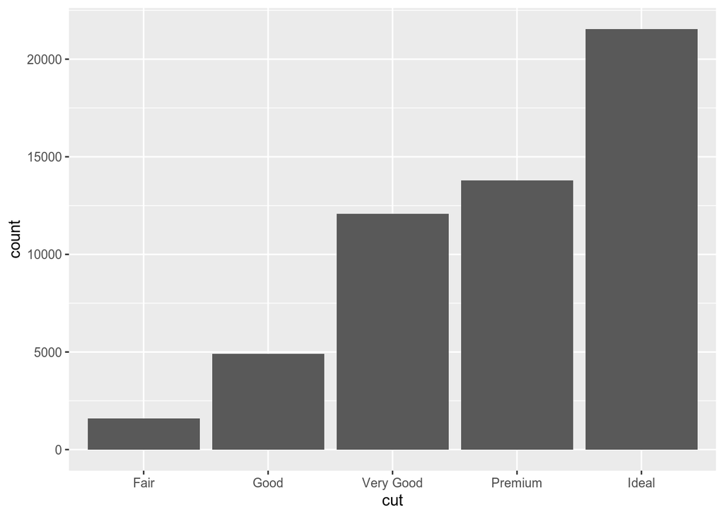

```r
ggplot(diamonds) +
  geom_bar(aes(x = cut))
```

Note that we used a bar graph and not a histogram here, bar charts are used for categorical values while histograms involve the use of binning continuous variables

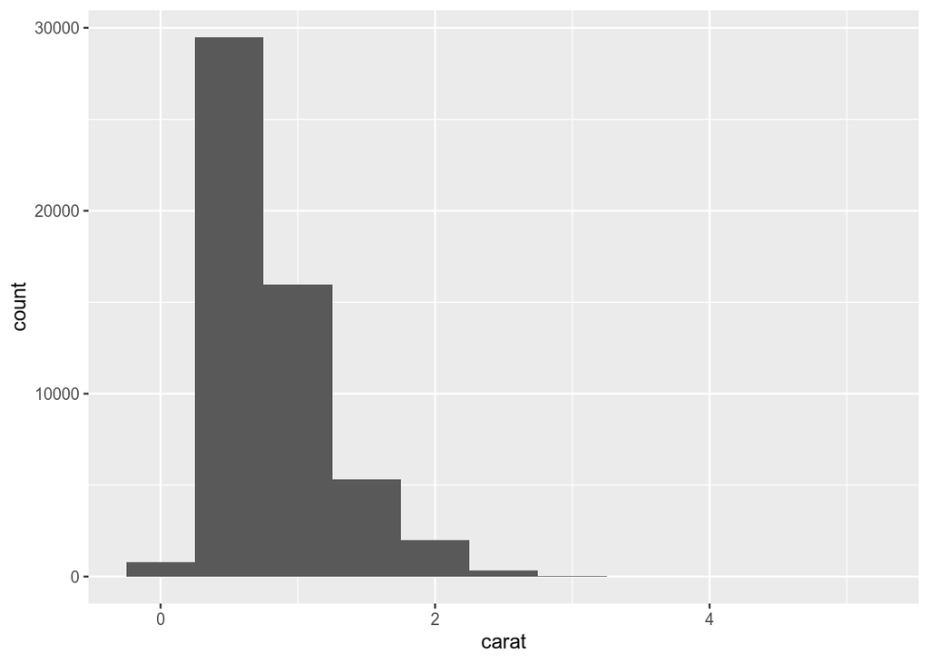

```r
ggplot(diamonds) +
  geom_histogram(aes(x = carat), binwidth = 0.5)
```

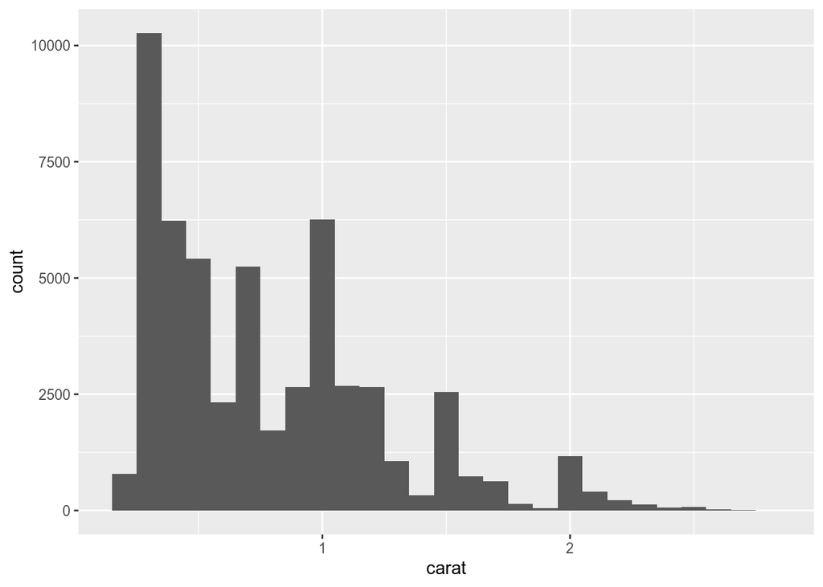

```r
smaller <- diamonds %>%
  filter(carat < 3)

ggplot(smaller, aes(x = carat)) +
  geom_histogram(binwidth = 0.1)
```

If we want to overlay muliple distributions of variables we can use frequency polygrams, a histogram though with a point at the middle of each bar

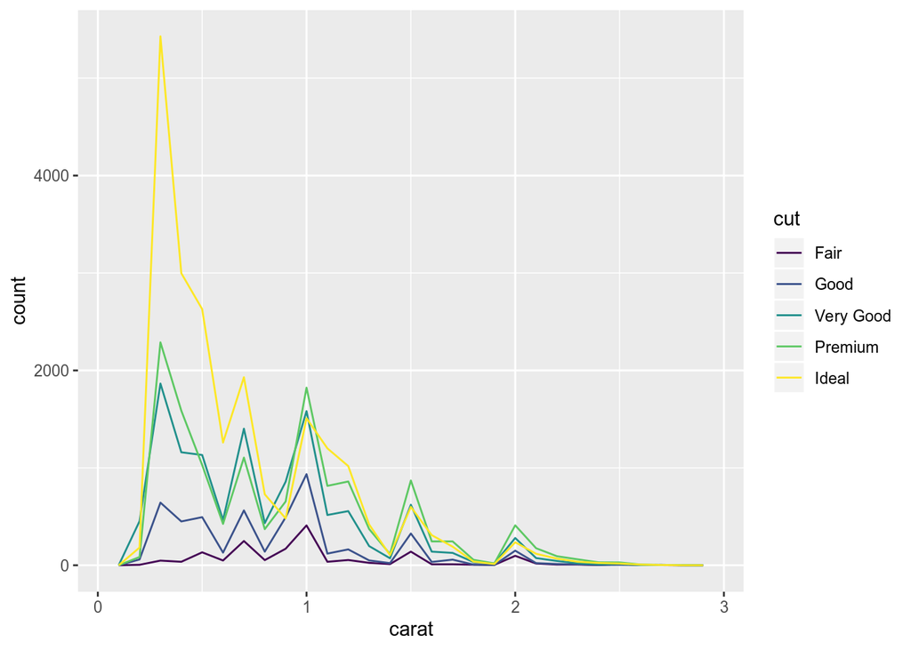

```r
ggplot(smaller, aes(x = carat, color = cut)) +
  geom_freqpoly(binwidth = 0.1)
```

Which values are the most common? Why?

Which values are rare? Why? Should we expect this?

Are there any unusual patterns? What might explain them?

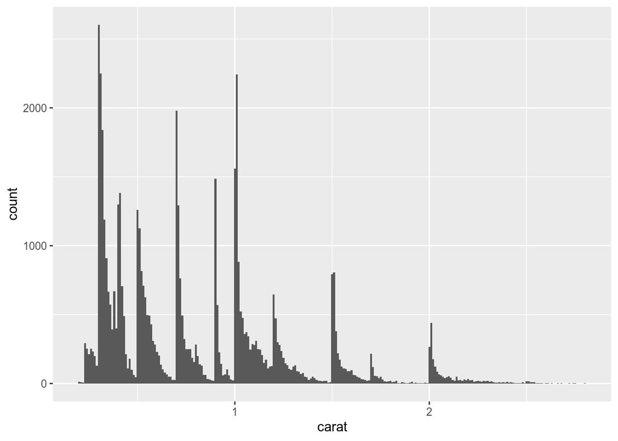

```r
ggplot(smaller, aes(x = carat)) +
  geom_histogram(binwidth = 0.01)
```

Why are there more diamonds at whole carasts and common fractions of carats?

Why are there more diamonds slightly to the right of each peak than there are slight to the left of each peak?

What are there no diamonds bigger than 3 carats?

Cluster of similar values suggest the existance of subgroups in the data, to understand these subgroups ask the following questions:

How are the observations within each cluster similar to eachother?

How are the observations in seperate clusters different from eachother?

How can the clusters be described?

Why might the appearance of the clusters be misleading?

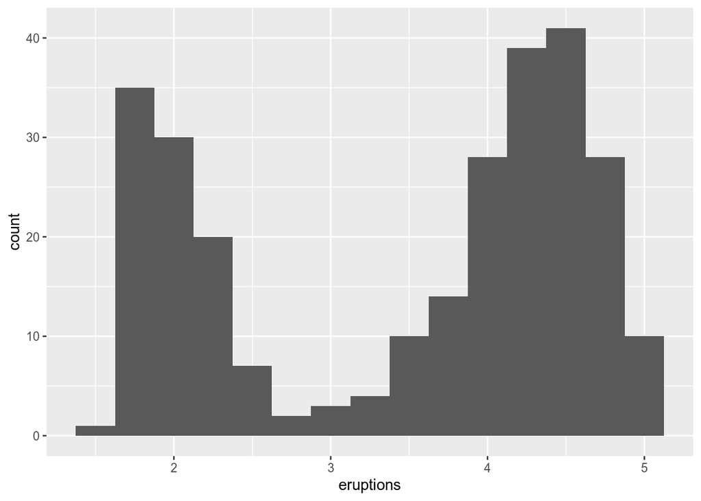

```r
ggplot(faithful, aes(x = eruptions)) +
  geom_histogram(binwidth = 0.25)
```

# Unusual Values

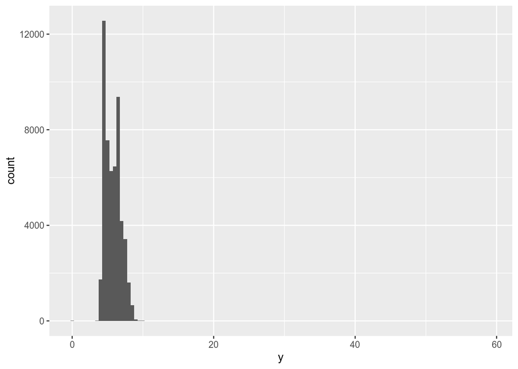

```r
ggplot(diamonds) +
  geom_histogram(aes(x = y), binwidth = 0.5)
```

With this binwidth its hard for us to even see the outlier values near 0. To help us see these values we can zoom in using the coord_cartesian() ggplot2 coordinate function

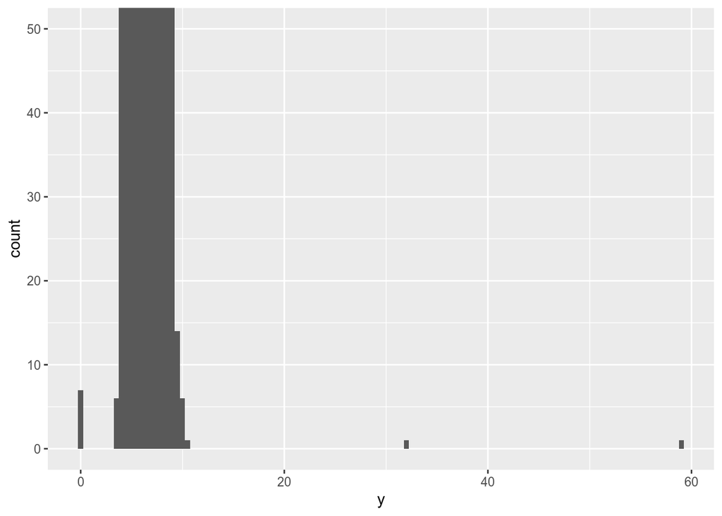

```r
ggplot(diamonds) +
  geom_histogram(aes(x = y), binwidth = 0.5) +
  coord_cartesian(ylim = c(0, 50))
```

Note that coord_cartesian() also has an xlim argument, and ggplot2 has seperate xlim() and ylim() functions that work slightly differently, by throwing away values outside of the limits

Zooming in on the y axis allows us to see three unusual values ~0, ~30, and ~60. Lets pluck them out with dplyr

```r
diamonds %>%
  filter(y < 3 | y > 20) %>%
  select(price, x, y, z) %>%
  arrange(y)
```

| price | x | y | z |
| --- | --- | --- | --- |
| 5139 | 0.00 | 0.0 | 0.00 |
| 6381 | 0.00 | 0.0 | 0.00 |
| 12800 | 0.00 | 0.0 | 0.00 |
| 15686 | 0.00 | 0.0 | 0.00 |
| 18034 | 0.00 | 0.0 | 0.00 |
| 2130 | 0.00 | 0.0 | 0.00 |
| 2130 | 0.00 | 0.0 | 0.00 |
| 2075 | 5.15 | 31.8 | 5.12 |
| 12210 | 8.09 | 58.9 | 8.06 |

It is good practice to repeat analyses with and without the outliers. If they have minimal effect on the result and we cannot figure out why they are there, it is reasonable to replace them with missing values (probably removing them). However if they have a substantial effect on the results, we should not just drop them without justification and need to figure out what caused them. (data entry error / etc …)

If we do encounter these unusual values and don’t think that they are valid, we have two options

1. Completely remove them
2. Replace the unusual values with missing values

```r
df <- diamonds %>%
  filter(between(y, 3, 20))
```

This is most likely not the best option as although one measurement is not valid, it does not mean that all of the measurements for the observation are garbage

It is best to replace these values with missing values, then to replace them with modified values (probably from interpolation)

```r
df <- diamonds %>%
  mutate(y = ifelse(y < 3 | y > 20, NA, y))
```

We can also use dplyr::case_when(), which is particularly useful when we want to create a new variable

```r
x <- 1:50

case_when(
  x%% 35 == 0 ~ "fizz buzz",
  x %% 5 == 0 ~ "fizz",
  x %% 7 == 0 ~ "buzz",
  TRUE ~ as.character(x)
)
```

```
##  [1] "1"         "2"         "3"         "4"         "fizz"
##  [6] "6"         "buzz"      "8"         "9"         "fizz"
## [11] "11"        "12"        "13"        "buzz"      "fizz"
## [16] "16"        "17"        "18"        "19"        "fizz"
## [21] "buzz"      "22"        "23"        "24"        "fizz"
## [26] "26"        "27"        "buzz"      "29"        "fizz"
## [31] "31"        "32"        "33"        "34"        "fizz buzz"
## [36] "36"        "37"        "38"        "39"        "fizz"
## [41] "41"        "buzz"      "43"        "44"        "fizz"
## [46] "46"        "47"        "48"        "buzz"      "fizz"
```

```r
diamonds %>%
  mutate(color = case_when(
    color == "E" ~ "Eerlily blue",
    color == "I" ~ "Indefinately black",
    color == "J" ~ "Joyasley teal",
    TRUE ~ "All diamonds are clear"
  )) %>% head(10)
```

| carat | cut | color | clarity | depth | table | price | x | y | z |
| --- | --- | --- | --- | --- | --- | --- | --- | --- | --- |
| 0.23 | Ideal | Eerlily blue | SI2 | 61.5 | 55 | 326 | 3.95 | 3.98 | 2.43 |
| 0.21 | Premium | Eerlily blue | SI1 | 59.8 | 61 | 326 | 3.89 | 3.84 | 2.31 |
| 0.23 | Good | Eerlily blue | VS1 | 56.9 | 65 | 327 | 4.05 | 4.07 | 2.31 |
| 0.29 | Premium | Indefinately black | VS2 | 62.4 | 58 | 334 | 4.20 | 4.23 | 2.63 |
| 0.31 | Good | Joyasley teal | SI2 | 63.3 | 58 | 335 | 4.34 | 4.35 | 2.75 |
| 0.24 | Very Good | Joyasley teal | VVS2 | 62.8 | 57 | 336 | 3.94 | 3.96 | 2.48 |
| 0.24 | Very Good | Indefinately black | VVS1 | 62.3 | 57 | 336 | 3.95 | 3.98 | 2.47 |
| 0.26 | Very Good | All diamonds are clear | SI1 | 61.9 | 55 | 337 | 4.07 | 4.11 | 2.53 |
| 0.22 | Fair | Eerlily blue | VS2 | 65.1 | 61 | 337 | 3.87 | 3.78 | 2.49 |
| 0.23 | Very Good | All diamonds are clear | VS1 | 59.4 | 61 | 338 | 4.00 | 4.05 | 2.39 |

Sometimes missing values mean something though, like in the case of missing dep_delay in nycflight13 means that the flights were cancelled

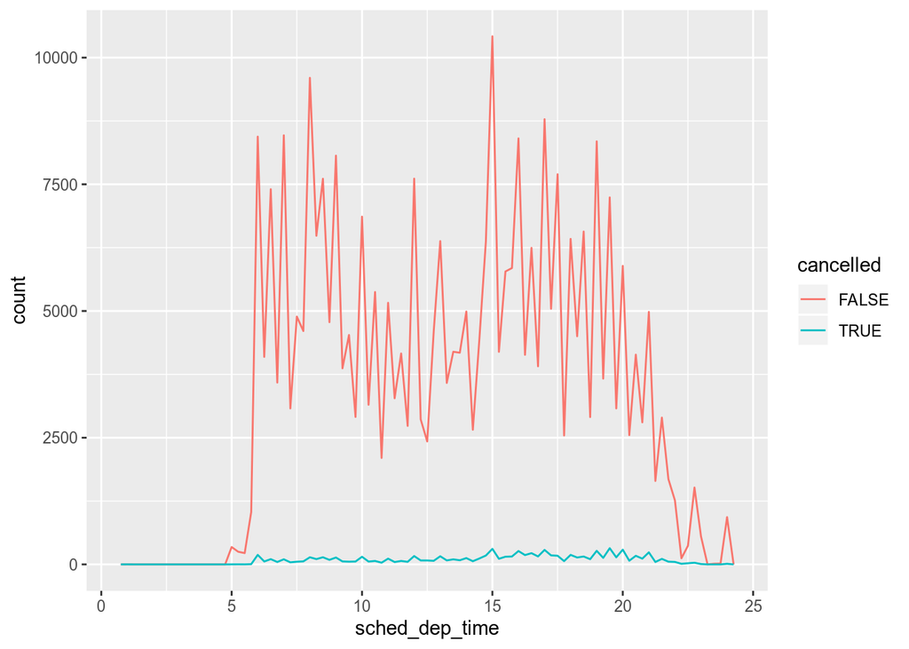

```r
nycflights13::flights %>%
  mutate(
    cancelled = is.na(dep_time),
    sched_hour = sched_dep_time %/% 100,
    sched_min = sched_dep_time %% 100,
    sched_dep_time = sched_hour + sched_min / 60
  ) %>%
  ggplot(aes(sched_dep_time)) +
    geom_freqpoly(aes(color = cancelled), binwidth = 1/4)
```

This isn’t a great way to summarise this data because there are much more non-cancelled flights than cancelled flights, we willcover this later.

# Covariation of variables

## A Categorical and Continuous Variable

It is common to want to explore the distribution of a continuous vriable broken down by categorical variable.

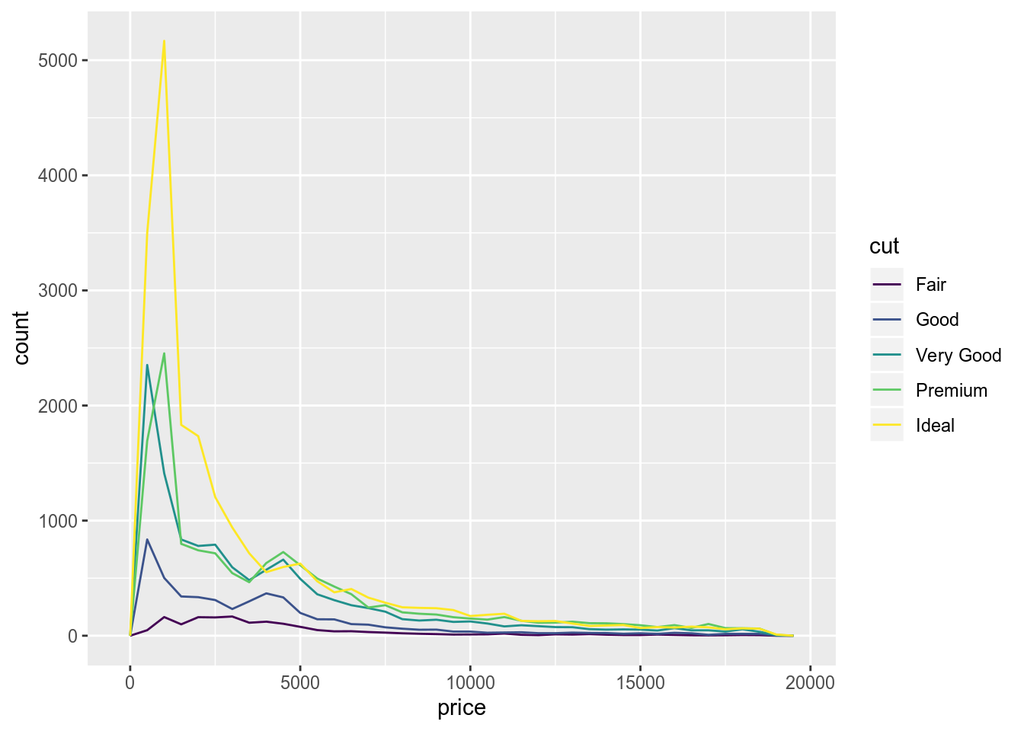

```r
ggplot(diamonds, aes(x = price)) +
  geom_freqpoly(aes(color = cut), binwidth = 500)
```

Its hard to see the difference in distribution because the overall counts vary so much

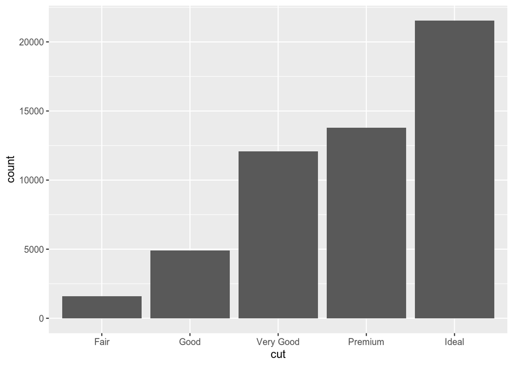

```r
ggplot(diamonds) +
  geom_bar(aes(x = cut))
```

To help in this scenario, we can change the y-axis to be density instead of count. Density is count but standardized so that the area under each frequency polygram is one

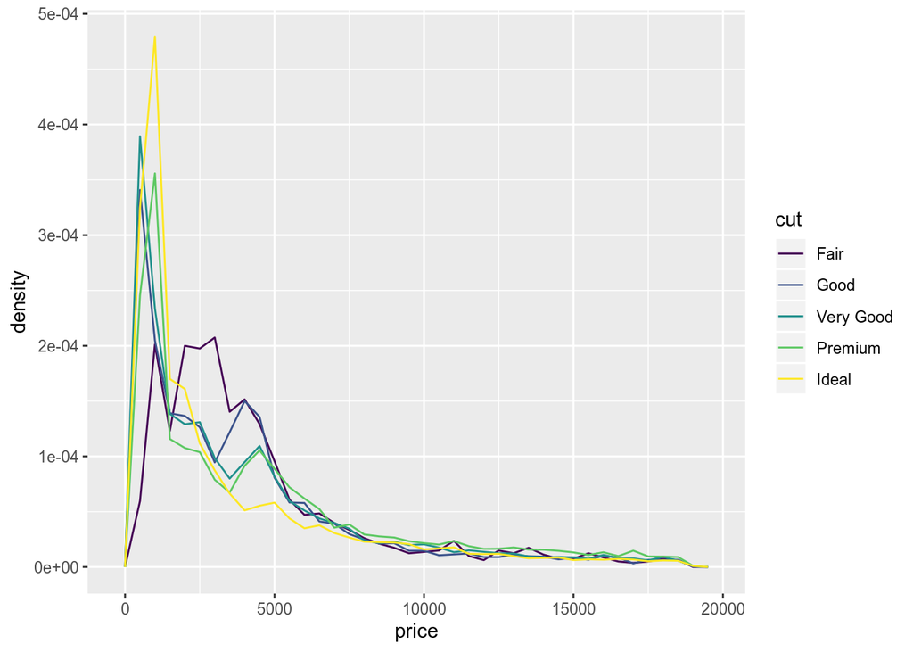

```r
ggplot(diamonds, aes(x = price, y = ..density..)) +
  geom_freqpoly(aes(color = cut), binwidth = 500)
```

what are things like ..count.., ..proportion.., and ..density.. called and where can I see documentation for them with a list of all possible items like it?

these special variables are returned from stat functions in ggplot, such as stat_bin (called implicilty by geom_histogram)

these special variables can be found on the ggplot2 cheat sheet: https://github.com/rstudio/cheatsheets/blob/master/data-visualization-2.1.pdf

This plot is a little hard to read so lets take a look at displaying the same data in a box plot

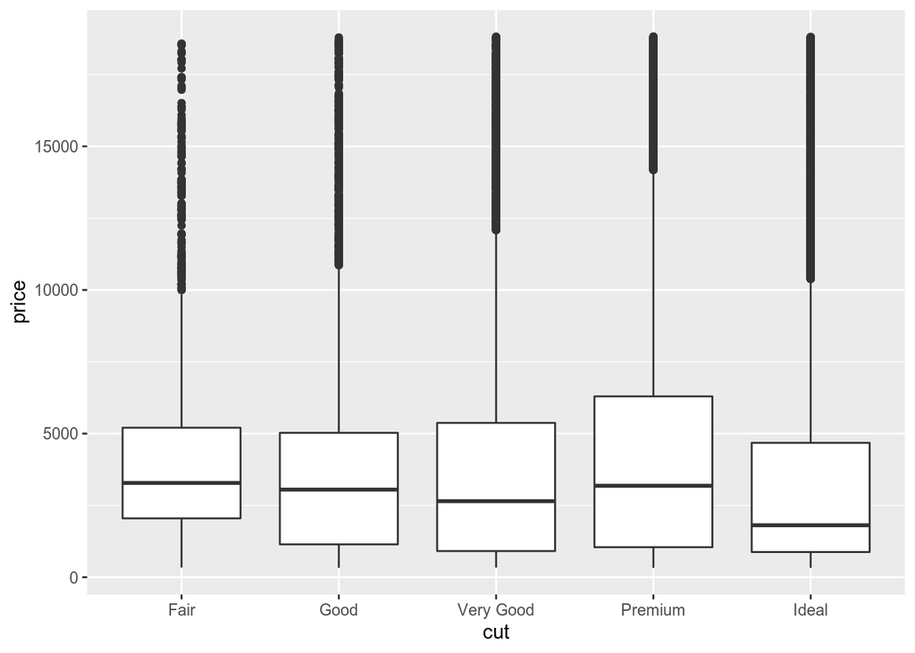

```r
ggplot(diamonds, aes(x = cut, y = price)) +
  geom_boxplot()
```

Here we see much less information about the distrobution of the data, though we can more easily compare the present distributions. The boxplot about supports the counterintuitive finding that better quality diamonds are cheaper on average!

Notice that `cut` is an ordered factor, fair being worse than good and so on.

Sometime we may want to reorder factor variables to behave a particular way. This can be achieved with the `reorder()` function.

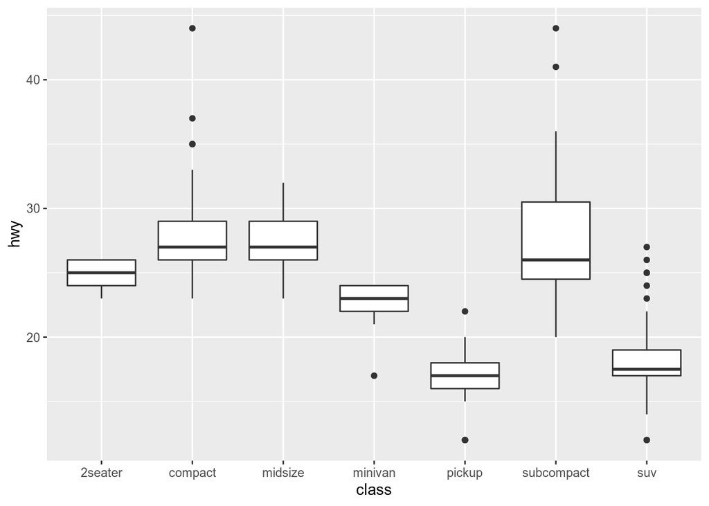

```r
ggplot(mpg, aes(x = class, y = hwy)) +
  geom_boxplot()
```

To make the trend more evident, lets use `reorder()` here.

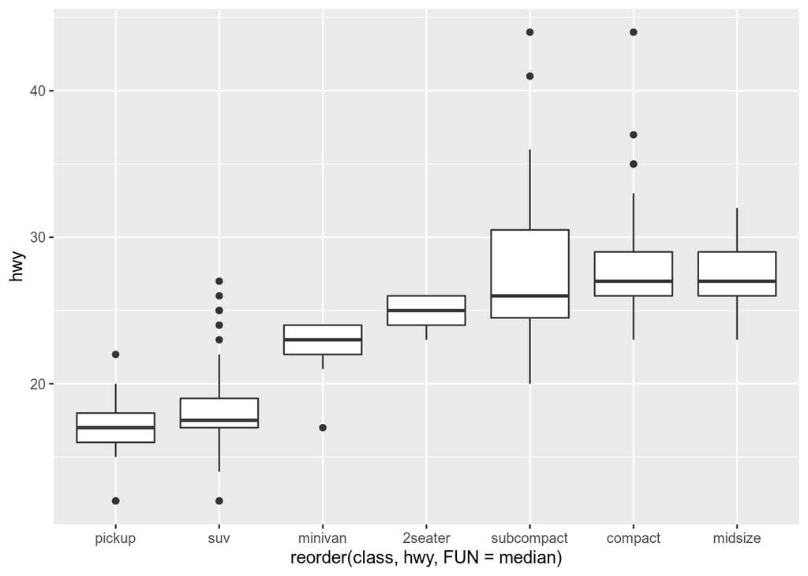

```r
ggplot(mpg) +
  geom_boxplot(aes(x = reorder(class, hwy, FUN = median), y = hwy))
```

This plot might be better seen on its side for labelling reasons.

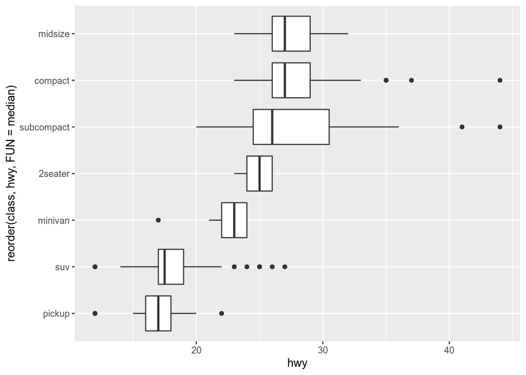

```r
ggplot(mpg) +
  geom_boxplot(aes(x = reorder(class, hwy, FUN = median), y = hwy)) +
  coord_flip()
```

**7.5.1.1 Question** What variable in the dataset is most important for predicting the price of a diamond? How is that variable correlated with cut? Why does the combination of these two relationships lead to lower quality diamonds being more expensive?

```r
vars <-
  diamonds %>%
  lapply(is.numeric) %>%
  unlist %>% which %>% names

vars %<>% syms

diamonds %>%
  select(!!!vars) %>%
  map(~cor(.x, diamonds$price)) %>%
  unlist %>% abs %>% sort
```

```
##     depth     table         z         y         x     carat     price
## 0.0106474 0.1271339 0.8612494 0.8654209 0.8844352 0.9215913 1.0000000
```

Here we see that `carat` is the most important predictive of price. Now how is this variable (carat) correlated with cut?

```r
diamonds %>%
  group_by(cut) %>%
  summarise(carat = median(carat))
```

| cut | carat |
| --- | --- |
| Fair | 1.00 |
| Good | 0.82 |
| Very Good | 0.71 |
| Premium | 0.86 |
| Ideal | 0.54 |

So it seems that the lowest quality diamonds are more costly than the highest quality diamonds as they tend to be much larger!

## Two Categorical Variables

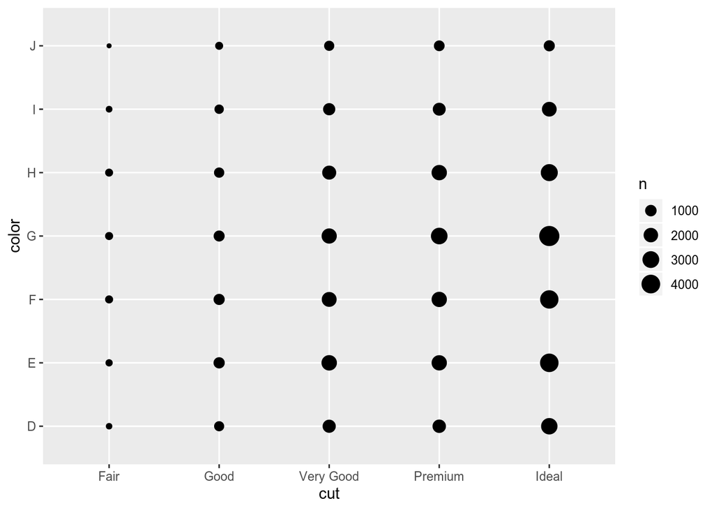

```r
ggplot(diamonds) +
  geom_count(aes(x = cut, y = color))
```

Here we used the `geom_count` geom, though we can acheive the same effect using `dplyr::count` along with `ggplot2::geom_tile`

```r
df <- diamonds %>%
  count(color, cut)

df %>% head(10)
```

| color | cut | n |
| --- | --- | --- |
| D | Fair | 163 |
| D | Good | 662 |
| D | Very Good | 1513 |
| D | Premium | 1603 |
| D | Ideal | 2834 |
| E | Fair | 224 |
| E | Good | 933 |
| E | Very Good | 2400 |
| E | Premium | 2337 |
| E | Ideal | 3903 |

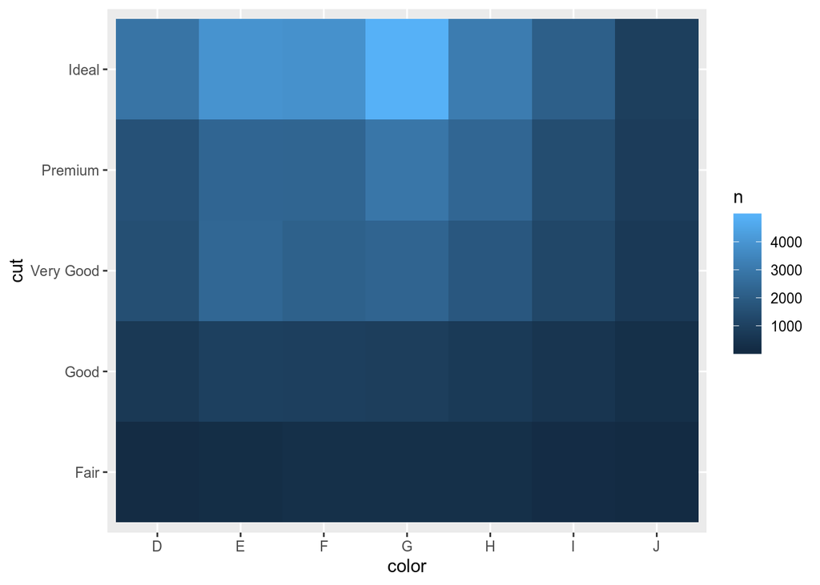

```r
df %>%
  ggplot(aes(x = color, y = cut)) +
  geom_tile(aes(fill = n))
```

I prefer the cleaner aesthetic of `ggplot2:geom_count`.

## Two Continous Variables

The most simple method, a scatter plot

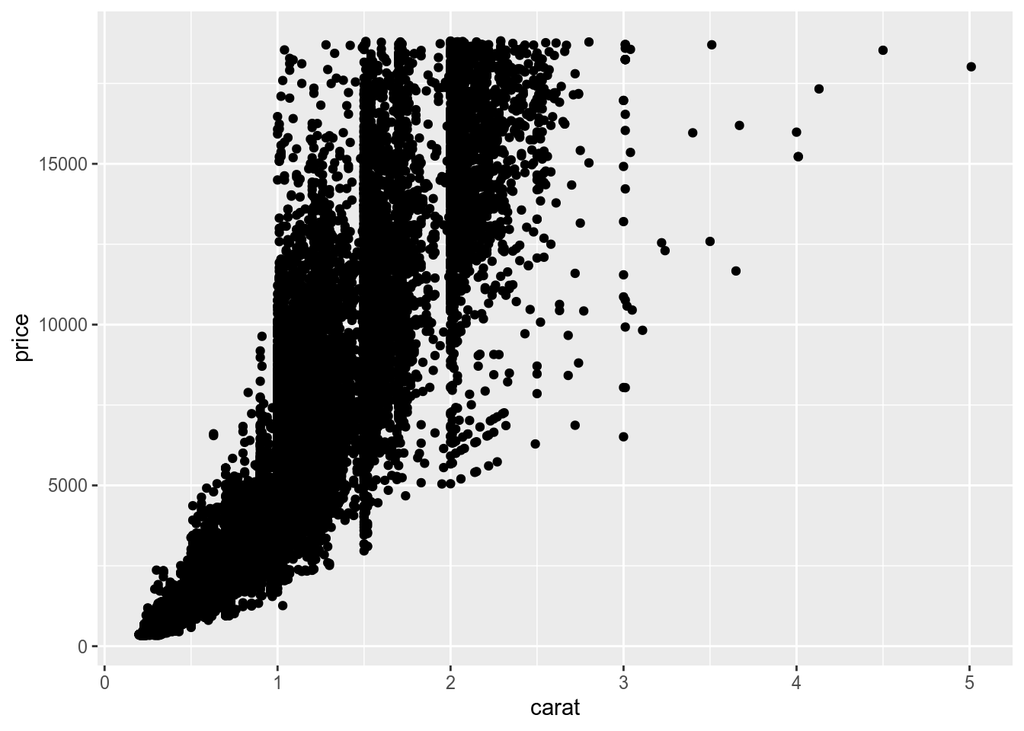

```r
ggplot(diamonds) +
  geom_point(aes(x = carat, y = price))
```

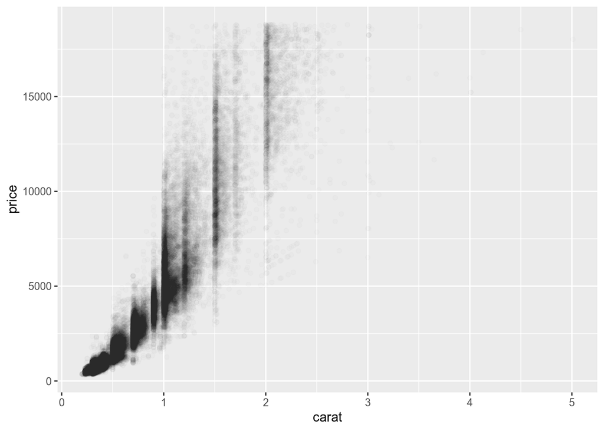

```r
ggplot(diamonds) +
  geom_point(aes(x = carat, y = price), alpha = .01)
```

Transparency can get dicey as well. This is when binning might be appropriate. We have seen `geom_histogram()` and `geom_freqpoly()` to bin one dimension. Now we will see `geom_bin2d()` and `geom_hex()` for two dimensional binning

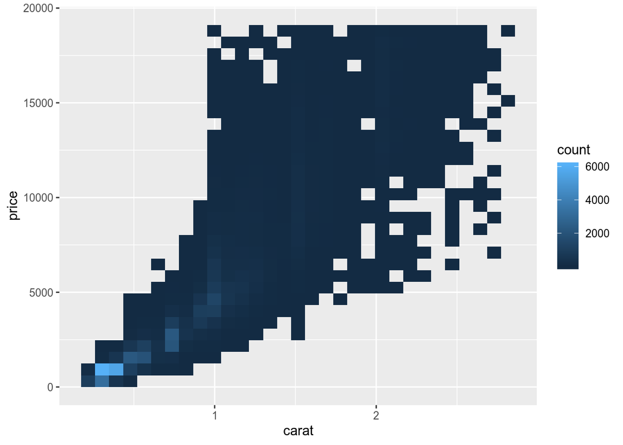

```r
ggplot(smaller) +
  geom_bin2d(aes(x = carat, y = price))
```

This seems to accomplish what adding alpha levels to scatterplots attempts to, though by adding another dimension of the color scale becomes much cleaner.

[figure not shown]

```r
# install.packages('hexbin')
ggplot(smaller) +
  geom_hex(aes(x = carat, y = price))
```

`geom_hex` is slightly nicer and more R community themed.

Another option to tackle data of this form is to bin one of the continous variable so that it acts like a categorical, then apply the previous methods for a singular continous and categorical variable that we have learned about.

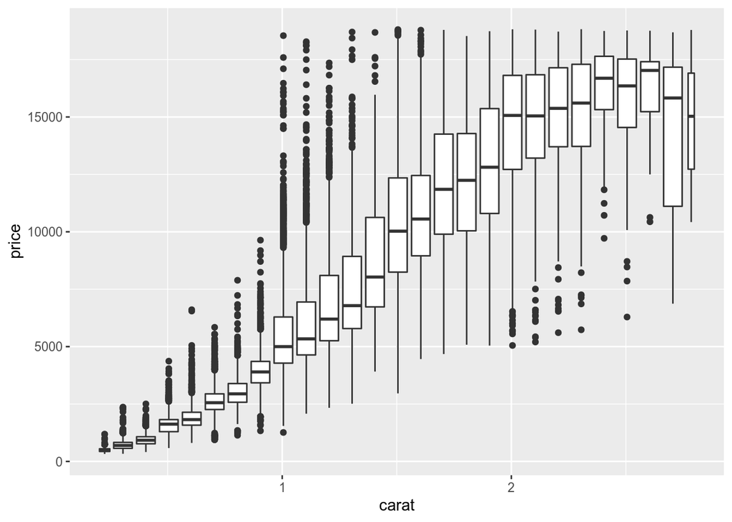

```r
ggplot(smaller, aes(x = carat, y = price)) +
  geom_boxplot(aes(group = cut_width(carat, 0.1)))
```

The `cut_width()` function used above divides `x` into bins of the provided width.

```r
cut_width(smaller$carat, 0.1) %>% first(5)
```

```
## [1] [0.15,0.25]
## 27 Levels: [0.15,0.25] (0.25,0.35] (0.35,0.45] (0.45,0.55] ... (2.75,2.85]
```

One final improvement on this

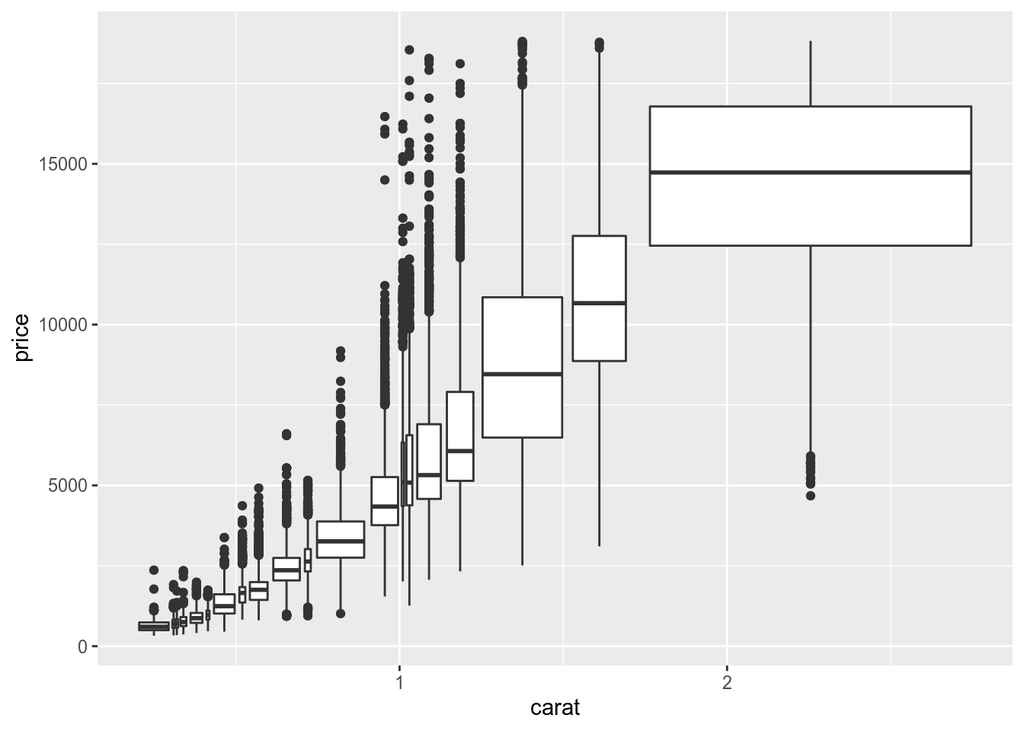

```r
ggplot(smaller, aes(x = carat, y = price)) +
  geom_boxplot(aes(group = cut_number(carat, 20)))
```

## Patterns and models

If we ever spot a pattern, we should first ask ourselves a few questions.

- Could this pattern be due to random chance?
- How could we describe the relationship implied by the pattern?
- How strong is the relationship implied by the pattern?
- What other variables might affect this relationship?
- Does the relations ship if we look at individual subgroups of the data?

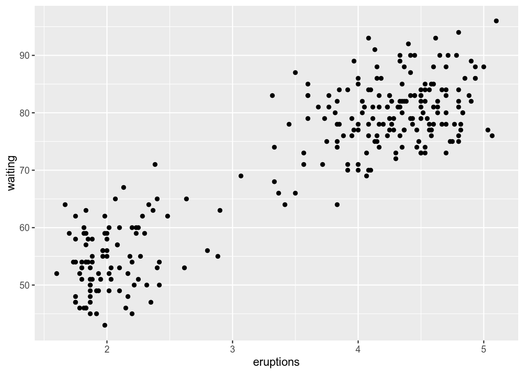

```r
ggplot(faithful) +
  geom_point(aes(x = eruptions, y = waiting))
```

Patterns are one of the most useful tools of data scientist as they reveal covariation. If we think of variation as a a phenomenon that creates uncertainty, covariation is a phenomenon that reduces it.

If two variables covary, and this is due to causual relationship, then we can use one vairbale to predict the other.

We will use the example of the `diamonds` dataset here. Its hard to understand the relationship between cut and price because cut and carat, and carat and price are so tightly related. We will attempt to use a model to remove the very strong relationship between price and carat so we can explore the subtleties that remain

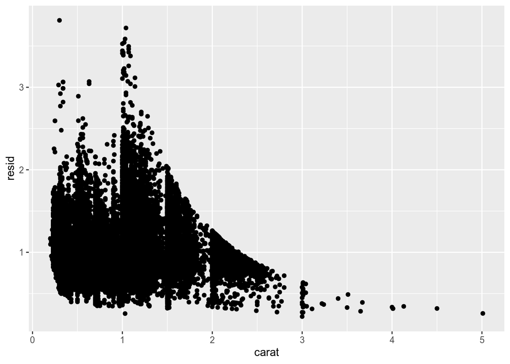

```r
library(modelr)

mod <- lm(log(price) ~ log(carat), data = diamonds)

df <- diamonds %>%
  add_residuals(mod) %>%
  mutate(resid = exp(resid))

ggplot(df) +
  geom_point(aes(x = carat, y = resid))
```

Once we remove the strong relationship between carat and price, we can see what we would expect in the relationship bettwen cut and price: relative to their size, better quality diamonds are more expensive.

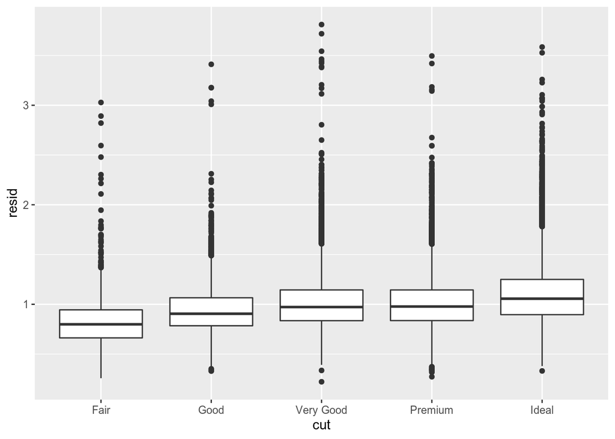

```r
ggplot(df) +
  geom_boxplot(aes(x = cut, y = resid))
```